# Project 1 - Applied Statistics

## Author - [Shekar Roy](https://github.com/shekarroy15)

# Part 1 of 3

## -------------------------------------------------------------------------------------------

## 1. Question:

Please refer the table below to answer below questions:

1. Refer to the above table and find the joint probability of the people who planned to purchase and actually placed an order.
2. Refer to the above table and find the joint probability of the people who planned to purchase and actually placed an order, given that people planned to purchase

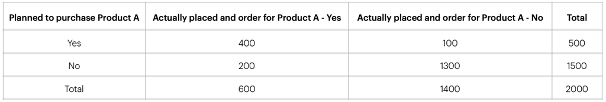

```python
#Solution derived by using joint probability

print('the joint probability of the people who planned to purchase and actually placed an order is ', 400/2000*100, '%')
print('the joint probability of the people who planned to purchase and actually placed an order, given that people planned to purchase is ', 400/500*100, '%')
```

```
the joint probability of the people who planned to purchase and actually placed an order is  20.0 %
the joint probability of the people who planned to purchase and actually placed an order, given that people planned to purchase is  80.0 %
```

## 2. Question:

An electrical manufacturing company conducts quality checks at specified periods on the products it manufactures. Historically, the failure rate for the manufactured item is 5%. Suppose a random sample of 10 manufactured items is selected. Answer the following questions.

A. Probability that none of the items are defective?

B. Probability that exactly one of the items is defective?

C. Probability that two or fewer of the items are defective?

D. Probability that three or more of the items are defective ?

```python
# values given
# n = 10
# p = 0.05 or 5%
# this follows a binomial distribution . hence we will use python's binom fn here

import numpy as np
import scipy.stats as stats

n = 10
p = .05
k=np.arange(0,11)
k
```

```
array([ 0,  1,  2,  3,  4,  5,  6,  7,  8,  9, 10])
```

```python
binomial = stats.binom.pmf(k,n,p)
binomial
```

```
array([5.98736939e-01, 3.15124705e-01, 7.46347985e-02, 1.04750594e-02,
       9.64808106e-04, 6.09352488e-05, 2.67259863e-06, 8.03789063e-08,
       1.58642578e-09, 1.85546875e-11, 9.76562500e-14])
```

```python
print('a) none of the items are defective is %1.4f' %binomial[0])
print('b) that exactly one of the items is defective is %1.4f' %binomial[1])
```

```
a) none of the items are defective is 0.5987
b) that exactly one of the items is defective is 0.3151
```

```python
# we need to calculate that two or fewer of the items are defective, we will use cumbinomial here

cumbinomial = stats.binom.cdf(k,n,p)
1 - cumbinomial[2]
print('c) that two or fewer of the items are defective is %1.4f' %cumbinomial[2])
```

```
c) that two or fewer of the items are defective is 0.9885
```

```python
# To answer three or more of the items are defective, we need to subtract cum prob upto 2 defective bulb from 1

D = 1- cumbinomial[2]
print('d)three or more of the items are defective is %1.4f' %D)
```

```
d)three or more of the items are defective is 0.0115
```

## 3. Question:

### A car salesman sells on an average 3 cars per week.

A. Probability that in a given week he will sell some cars.

B. Probability that in a given week he will sell 2 or more but less than 5 cars.

C. Plot the poisson distribution function for cumulative probability of cars sold per-week vs number of cars sold perweek.

```python
# given `n=3`
# now out the above in Poisson formaule, and will calculate the probabilities
# (a)"Some cars" can mean" 1 or more cars":
# P(X>0) = 1 − P(xo)
# 𝑃(𝑋=xo)= 30(0 is raised to) * e−3 / 0!
# hence 𝑃(𝑋=>1)

print ('probability of selling some car is', 0.95021*100, '%')
```

```
probability of selling some car is 95.021 %
```

```python
## import packages for doing below calcs

import numpy as np
import matplotlib.pyplot as plt
import scipy.stats as stats
```

```python
# (b) The probability of selling 2 or more cars, but less than 5 cars is:
rate=3
n=np.arange(0,10)
poisson = stats.poisson.pmf(n,rate)
P1 = poisson[4] # less than 5 cars
P2 = poisson[1] # >= 2 cars
P = P1 - P2
print(' b) Probability that the agent sells between 2 and 5 cars is %1.4f' % P)
```

```
 b) Probability that the agent sells between 2 and 5 cars is 0.0187
```

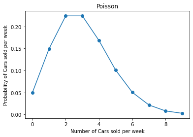

```python
poisson = stats.poisson.pmf(n,rate)
plt.plot(n,poisson, 'o-')
plt.title('Poisson')
plt.xlabel('Number of Cars sold per week')
plt.ylabel('Probability of Cars sold per week')
plt.show()
```

## 4. Question:

Accuracy in understanding orders for a speech based bot at a restaurant is important for the Company X which has designed, marketed and launched the product for a contactless delivery due to the COVID-19 pandemic. Recognition accuracy that measures the percentage of orders that are taken correctly is 86.8%. Suppose that you place order with the bot and two friends of yours independently place orders with the same bot. Answer the following questions.

A. What is the probability that all three orders will be recognised correctly?

B. What is the probability that none of the three orders will be recognised correctly?

C. What is the probability that at least two of the three orders will be recognised correctly?

```python
#given data
accurate = .868
not_accurate = .132

all_rec = accurate*accurate*accurate
none_rec = not_accurate*not_accurate*not_accurate

print(' a) all orders are recognised', round(all_rec,4))

print(' b) none orders are recognised', round(none_rec,5))

# part c can be termed as -> first(OK), second(OK), third(NOT_OK), 3 possibilties as such
probab = accurate*accurate*not_accurate
print('c) at least two of the three orders will be recognised correctly', round(probab+all_rec,4))
```

```
 a) all orders are recognised 0.654
 b) none orders are recognised 0.0023
c) at least two of the three orders will be recognised correctly 0.7534
```

## 5. Question:

A group of 300 professionals sat for a competitive exam. The results show the information of marks obtained by them have a mean of 60 and a standard deviation of 12. The pattern of marks follows a normal distribution. Answer the following questions.

A. What is the percentage of students who score more than 80.

B. What is the percentage of students who score less than 50.

C. What should be the distinction mark if the highest 10% of students are to be awarded distinction?

```python
#(X)=80, mu=60, sigma=12
# calculate Z
#(80-60)/12
# 1.66
# This is the distinction mark that will be scored by 10% of the students.
# more than 80
# calculate Z score z= (80-60)/12 = 1.66, look up the z-table
print('a) % of student with > 80 marks = 45.15%')
print ('')
# calculate Z score z= (50-60)/12 = -0.83, look up the z-table
print('b) % of student with < 50 marks = 29.39%')
X= 1.66*12+60
print('')
print('c) the distinction marks is %1.4f' %X)
```

```
a) % of student with > 80 marks = 45.15%

b) % of student with < 50 marks = 29.39%

c) the distinction marks is 79.9200
```

## 6. Question:

Explain 1 real life industry scenario [other than the ones mentioned above] where you can use the concepts learnt in this module of Applied statistics to get a data driven business solution.

For example, a study has shown that more than 75% of people are infected with a disease that is caused by grapes. In that case, you might avoid grapes to avoid this disease.